# Lambert Network

Floriane Goy working on a script of Simon Gabay

2025-03-27

# 1 Introduction

## 1.1 bibliographie

```
@manual{schweinberger`2024coll,
  author = {Schweinberger, Martin},
  title = {Analyzing Collocations and N-grams in R},
  note = {https://ladal.edu.au/coll.html},
  year = {2024},
  organization = {The University of Queensland, Australia. School of Languages and Cultures},
  address = {Brisbane},
  edition = {2024.03.28}
}
```

tutorial one https://slcladal.github.io/coll.html#Co-occurrence_and_association2

## 1.2 vérification du système

1. On installe les commandes de base
2. verifier le chemin R et Python :

(mais peut-être 3.9 pourrait être plus adéquat.)

```r
system("python --version", intern = TRUE)
```

```
## [1] "Python 3.8.20"
```

```r
system("which python", intern = TRUE)
```

```
## [1] "/usr/bin/python"
```

```r
system("which R", intern = TRUE)
```

```
## [1] "/usr/bin/R"
```

# 2 Setup

On indique sur quel dossier on va travailler

## 2.1 Load packages

On choisit le serveur hébergeant le dépot Cran.

```r
# Set CRAN mirror interactively to ETH Zurich (mirror 63)
# chooseCRANmirror() and choose 63 for switzerland e.g.
options(repos = c(CRAN = "https://stat.ethz.ch/CRAN/"))
```

On installe les packages necessaires

les packages permettent des traitements diverses de l’information :

- **Text Analysis & Processing**
  - **Text Mining & NLP** (`quanteda`, `tm`, `stopwords`, `udpipe`, `tidytext`)
  - **Text Prediction** (`sbo`)
  - **String Manipulation** (`stringr`, `stringi`, `magrittr`)
  - **Collostructional Analysis** (`collostructions`)
- **Data Analysis & Transformation**
  - **Data Processing** (`dplyr`)
  - **Sparse Matrices** (`Matrix`)
  - **Information Theory & Feature Selection** (`infotheo`)
- **Topic Modeling & Clustering**
  - **Latent Dirichlet Allocation (LDA)** (`topicmodels`, `LDAvis`, `ldatuning`)
  - **Dimensionality Reduction** (`tsne`)
- **Network & Graph Analysis**
  - **Network Structures & Graphs** (`igraph`, `network`, `sna`)
- **Data Visualization**
  - **General Data Visualization** (`ggplot2`)
  - **Dendrogram Visualization** (`ggdendro`)
  - **Word Clouds** (`wordcloud`, `wordcloud2`)
  - **Color Palettes** (`RColorBrewer`)
- **Utility Tools**
  - **Local Web Server & Reporting** (`servr`)

```r
# set options
options(stringsAsFactors = F)
options(scipen = 999)
options(max.print=1000)

install.packages("dplyr")
install.packages("ggplot2")
install.packages("sbo")
install.packages("stringr")
install.packages("tm")
install.packages("visNetwork")

# install packages
```

ajout package

```r
#install.packages("visNetwork")
```

installer quanteda depuis le dépôt général.

```r
install.packages("quanteda", repos = "http://cran.r-project.org")
install.packages("quanteda.textstats", repos = "http://cran.r-project.org")
```

```r
install.packages("quanteda.textplots", repos = "http://cran.r-project.org")
# install klippy for copy-to-clipboard button in code chunks
install.packages("remotes")
remotes::install_github("rlesur/klippy")
```

On charge les packages

```r
# activate klippy for copy-to-clipboard button
#remotes::install_github("rlesur/klippy")
#klippy::klippy()
#library(FactoMineR)
#library(factoextra)
#library(flextable)
#library(ggdendro)
#library(igraph)
#library(network)
#library(Matrix)
library(quanteda)
library(quanteda.textstats)
library(quanteda.textplots)
library(dplyr)
library(stringr)
library(tm)
library(sbo)
#library(sna)
#library(magrittr)
library(stopwords)
#library(GGally)
#library(udpipe)
#library(infotheo)
#library(ldatuning)
library(ggplot2)
#library(topicmodels)
#library(wordcloud)
#library(wordcloud2)
#library(RColorBrewer)
#library(stringi)
#library(LDAvis)
#library(tsne)
#library(servr)
#library(tidytext)
library(visNetwork)
```

### 2.1.1 problème de librairie

lorsqu’on télécharge souvent les mêmes programmes, ils peuvent s’intaller de manière incomplete. le code ci-dessus permet de supprimé une libraire. Il suffir ensuite de la réinstaller proprement.

```r
#unlink("/home/floriane/R/x86_64-pc-linux-gnu-library/4.4/00LOCK-quanteda", recursive = TRUE)
```

# 3 lemmatisation

Les analyses de réseau en latin demande une lemmatisation du corpus, or ce procedé est complexifié par l’état de langue des texte du 16eme siècle.

Concernant la lemmatisation, on utilise une approche 1. des données annotés automiquement par [Pyrrha](https://dh.chartes.psl.eu/pyrrha/) , augumentée et corrigée à la main.

2. il existe d’autres méthodes à tester dans un second temps
   - automatiser la lemmatisation avec CLTK:

     -Un très bon tutorial : Introduction to NLP and CLTK (Latin NLP with Python) : https://www.youtube.com/watch?v=OtxC44b1rws
   - travailler sur le topic-modelling [LatinBert](https://github.com/dbamman/latin-bert)

Dans notre cas, les données lemmatisées dans Pyrrha sont nettoyées avant la lemmatisation avec le script suivant : clean_prelematisation.Rmd

ici on utilise la lemmatisation automatisée avec cltk : cf notebook Lemmatisation_cltk/lem2_test.ipynb

# 4 comparer des dataset

```r
#when we use a range of file have a main folder and all the file.txt inside : use this code
list_of_files <- list.files(path = "./Lambertus_Tim_1.2/", recursive = TRUE,
                            pattern = "\\.txt$",
                            full.names = TRUE)
#install.packages("tidyverse", repos = "https://cran.rstudio.com")
#assuming tab separated values with a header
datalist = lapply(list_of_files, function(x)paste(scan(x, what="character", sep="", fileEncoding="UTF-8"),collapse=" "))
```

```r
#save the file for control
fileConn<-file("corpus_clean.txt")
writeLines(as.character(datalist), fileConn)
close(fileConn)
```

# 5 nettoyage des données

## 5.1 donnée pyrrha

on travail avec un fichier tsv contenant un texte lemmatiser avec Pyrrha: * on doit recréer le texte à partir de tsv

```r
# Define a list (or vector) of file paths to your lemmatized TSV files
datalist <- c("Aretius_Tim_1.1-6/Caput_2/aretius-2_lemmatized.txt")  # add more file paths if needed
increment <- 0
mybiglist <- list()
for(file_path in datalist){
  # Read the TSV file (adjust header and separator if needed)
  x <- read.delim(file_path, header = TRUE, sep = "\t", stringsAsFactors = FALSE)
  textLemmat <- ""
  if(nrow(x) != 0){
    # Extract the first lemma token
    textLemmat <- x$lemma[1]
    # Loop through the remaining rows/tokens
    for(i in 2:nrow(x)){
      if(!is.na(x$lemma[i])){
        textLemmat <- paste(textLemmat, x$lemma[i], sep = " ")
      }
    }
  }
  increment <- increment + 1
  mybiglist[[increment]] <- textLemmat
}
corpus_lemmatised <- mybiglist
corpus_lemmatised[[1]][1]
```

```
## [1] "caput . duo sum1 fidelis2 officium in publicus2 coetus : audio sanus doctrina ex uerbum deus , et2 cum2 totus coetus prex ad2 dominus fundo2 . de prior iam ago sum1 caput eo1 primo . nunc ad2 alter descendo , admoneo Timotheus ut4 suus auctor sum1 in Ephesinus ecclesia , ut4 in prex seruo pi…
```

## 5.2 donnée cltk

On travaille avec un text déjà lemmatisées avec cltk

```r
# Define a list of file paths
datalist <- c("Lambertus_Tim_1.2/Lamb_chap_2_lematized.txt")  # Add more file paths if needed

increment <- 0
mybiglist <- list()

for(file_path in datalist){

  # Read the content of the file
  text_data <- readLines(file_path, warn = FALSE)  # Read the file into a character vector

  # Combine the lines into one single text string
  text_combined <- paste(text_data, collapse = " ")

  increment <- increment + 1
  mybiglist[[increment]] <- text_combined

}

# Store the result in corpus_lemmatised
corpus_lemmatised <- mybiglist

# Display the first element
corpus_lemmatised[[1]]
```

```
## [1] "cap. ii . adhortor igitur ante omnis vt facio deprecatio , prex , postulatio , gratia actio pro qui uis homo . Transitio sum ad alter euangelicus munus pars , qui sum publicus precus pro quilibet homo genus conceptio et profusio coram deus . qui disputatio commode subicio tum ad suscipio arg…
```

- sauvegarder le document dans un fichier texte pour vérifier sa Structures (étape à supprimer plus tard)

```r
fileConn<-file("corpus_clean_lemmatised.txt")
writeLines(as.character(corpus_lemmatised), fileConn)
close(fileConn)
```

construire un dataset pour comparer les documents entre eux:

```r
document <- list_of_files
texteLemmat <- unlist(corpus_lemmatised)

df <- data.frame(document, texteLemmat)

print(df)
```

```
##                                         document
## 1 ./Lambertus_Tim_1.2//Lamb_chap_2_lematized.txt
##                                                                                                                                                                                                                                                                                                          …
## 1 cap. ii . adhortor igitur ante omnis vt facio deprecatio , prex , postulatio , gratia actio pro qui uis homo . Transitio sum ad alter euangelicus munus pars , qui sum publicus precus pro quilibet homo genus conceptio et profusio coram deus . qui disputatio commode subicio tum ad suscipio argume…
```

# 6 premier nettoyage des données pour les coocurrences :

pour travailler sur les cooccurrences on conserve la puctuation qui permet de découper le document en phrase. * plus tard, il s’agira de le découper par verset.

```r
#keep filename, get rid of the path
df<-df %>%
  mutate(document = word(document, -1, sep = "/"))
#remove punctuation
df$texteLemmat<-gsub('[[:punct:] ]+',' ',df$texteLemmat)
#remove numbers
df$texteLemmat<-gsub('[[:digit:] ]+',' ',df$texteLemmat)
print(df)
```

```
##                    document
## 1 Lamb_chap_2_lematized.txt
##                                                                                                                                                                                                                                                                                                          …
## 1 cap ii adhortor igitur ante omnis vt facio deprecatio prex postulatio gratia actio pro qui uis homo Transitio sum ad alter euangelicus munus pars qui sum publicus precus pro quilibet homo genus conceptio et profusio coram deus qui disputatio commode subicio tum ad suscipio argumentum quia pasto…
```

# 7 créatuon du DTM

création d’un DTM : document term matrix détermine la fréquence des mots dans le document sur forme de valeur numerique

```r
corpusTM <- Corpus(VectorSource(df$texteLemmat), readerControl = list(language = "lat"))
ncol(as.matrix(DocumentTermMatrix(corpusTM)))
```

```
## [1] 2184
```

```r
corpusTM[[1]][[1]]
```

```
## [1] "cap ii adhortor igitur ante omnis vt facio deprecatio prex postulatio gratia actio pro qui uis homo Transitio sum ad alter euangelicus munus pars qui sum publicus precus pro quilibet homo genus conceptio et profusio coram deus qui disputatio commode subicio tum ad suscipio argumentum quia pa…
```

On supprimer les mots les plus frequents en enlevant les stopwords

```r
stopword_enLigne = read.csv("./stopwords/latin_stop_word.csv", header=FALSE, stringsAsFactors=FALSE)[,]
corpus_clean <- tm_map(corpusTM, removeWords, stopword_enLigne)
corpus_clean[[1]][[1]]
```

```
## [1] "cap  adhortor    vt facio deprecatio prex postulatio gratia actio   uis homo Transitio    euangelicus munus pars   publicus precus  quilibet homo genus conceptio  profusio coram deus  disputatio commode subicio   suscipio argumentum  pastor ecclesia   munus pars paulus informo    superior co…
```

```r
#save the file for control
fileConn<-file("corpus_clean_lemmatised.txt")
writeLines(as.character(corpus_clean), fileConn)
close(fileConn)
```

on sauvegarde les données dans une matrice

```r
dtm <- DocumentTermMatrix(corpus_clean)
rownames(dtm) <- df$document
```

# 8 premières analyse de fréquence:

Un première examen des fréquences statistiques permet de visualiser les mots importants, de poser les bases d’un topic modeling. * pour l’instant on se concentre sur les fréquence de mots.

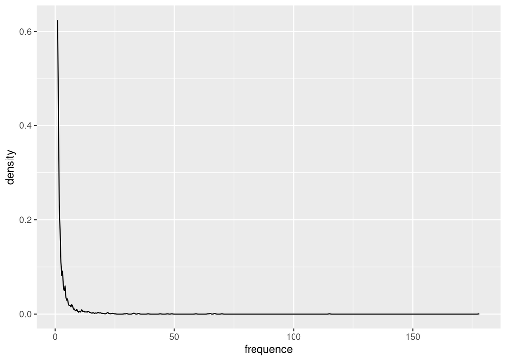

```r
freq <- as.data.frame(colSums(as.matrix(dtm)))
colnames(freq) <- c("frequence")
#Je dessine mon graph
ggplot(freq, aes(x=frequence)) + geom_density()
```

```r
# pour voir un historiogramme :
#ggplot(freq, aes(x = frequence)) + geom_histogram(bins = 30, fill = "blue", alpha = 0.5)
```

# 9 nettoyage des mots peu fréquent

- création d’un set de data proteger qui contiennent les mots récurrents mais signifiant du vocabulaire théologique:

```r
# CONTINUE LATIN TEXT CLEANING SCRIPT
# 1. Define protected terms (customize this list) here the theological vocabulary
protected_terms <- c("deus", "christus", "spiritus", "ecclesia", "dominus")
```

# 10 identification des mots peu fréquents

```r
# 2. Remove LOW frequency words (0-49 occurrences)
motsPeuFrequents <- findFreqTerms(dtm, 0, 49)
dtm_mid <- dtm[, !colnames(dtm) %in% motsPeuFrequents]
head(motsPeuFrequents,100)
```

```
##   [1] "aberro"        "abigo"         "abiicio"       "abolesco"
##   [5] "abraham"       "abrahamus"     "abrupo"        "absque"
##   [9] "abstersio"     "abstineo"      "absum"         "absurdus"
##  [13] "accedo"        "acceptor"      "accipio"       "accommodo"
##  [17] "aces"          "acquiesco"     "act"           "actio"
##  [21] "actor"         "actus"         "adam"          "addico"
##  [25] "addo"          "adduco"        "adhibeo"       "adhorto"
##  [29] "adhortor"      "adiapho"       "adimo"         "aditus"
##  [33] "adiungo"       "adiutorium"    "administratio" "administro"
##  [37] "adnuntio"      "ado"           "adoro"         "adrianus"
##  [41] "adsto"         "aduersus"      "adulatio"      "aduno"
##  [45] "aduoco"        "aedificatio"   "aedificium"    "aedifico"
##  [49] "aequalis"      "aequaliter"    "aequis"        "aequiualens"
##  [53] "aequor"        "aequus"        "aerumnus"      "aestimabilis"
##  [57] "aestimo"       "aetas"         "aeternus"      "affectatio"
##  [61] "affectus"      "affero"        "affligo"       "affrica"
##  [65] "agens"         "agnis"         "agnitio"       "agnoscero"
##  [69] "agnosco"       "ago"           "agrestis"      "aio"
##  [73] "ais"           "alatcor"       "albus"         "alexander"
##  [77] "alexandr"      "alibi"         "alienus"       "alioqui"
##  [81] "aliqui"        "alleget"       "alligo"        "alo"
##  [85] "altare"        "amazonus"      "ambitio"       "ambrosius"
##  [89] "americus"      "amicio"        "amicus"        "amo"
##  [93] "amplus"        "anabaptista"   "anceps"        "ancilla"
##  [97] "angelus"       "anglia"        "animaduo"      "animus"
```

# 11 identification des mots très fréquents

```r
motsTresFrequents <- findFreqTerms(dtm, 20, Inf)
#Si vous êts sur windows, décommentez la ligne suivante
#Encoding(motsTresFrequents)<-"latin-1"
length(motsTresFrequents)
```

```
## [1] 37
```

```r
head(motsTresFrequents,100)
```

```
##  [1] "animus"      "caput"       "christianus" "christus"    "confirmo"
##  [6] "constituo"   "debeo"       "deus"        "dico"        "doceo"
## [11] "ecclesia"    "facio"       "fides"       "genus"       "homo"
## [16] "liber"       "libus"       "locus"       "magnus"      "mulier"
## [21] "oratio"      "oro"         "paulus"      "preco"       "prex"
## [26] "publicus"    "quaero"      "ratio"       "sanctus"     "sententia"
## [31] "siue"        "tempus"      "totus"       "verbum"      "versus"
## [36] "video"       "vis"
```

le résultat affiche les mots les plus fréquents sans filtrage préalable on peut donc vérifier s’il y a des mots non signifiant qui apparaissent par erreur dans la statistique. ici: versus, locus, caput font parti du lexique de l’analyse de texte.  
On peut les retirer plus tard.

# 12 script de nettoyage II

- je supprime les mots non signifiant récurrents
- je supprime tous les textes suvis d’un point directement pour enlever les abréviations.

```r
# Define your stopwords list
MesStopWords <- c("que", "uel", "caput", "uersus",
                  "versus", "quartus", "contra", "vt",
                   "locus", "siue", "liber", "libus",
                   "quemadmodum", "quanquam")

# Custom function to clean text
clean_text <- function(text) {
  # Remove words followed by a period
  text <- gsub("\\b\\w+\\.\\s*", "", text)
  text <-gsub("æ", "ae", text)
  # Remove stopwords (case insensitive)
  words <- unlist(strsplit(text, "\\s+"))
  words <- words[!tolower(words) %in% tolower(MesStopWords)]
  text <- paste(words, collapse = " ")
  return(text)
}

# Apply cleaning to your corpus_clean object
cleaned_text <- clean_text(as.character(corpus_clean))

# Save the cleaned file
fileConn <- file("corpus_clean_lemmatised.txt")
writeLines(cleaned_text, fileConn)
close(fileConn)
```

## 12.1 Co-occurrences

### 12.1.1 Pre-processing

We split the text into sentences (to create a context for the co-occurrences):

```r
full_data <- readLines("corpus_clean_lemmatised.txt")

# Apply the normalization to each line
cleaned_data <- sapply(full_data, clean_text, USE.NAMES = FALSE)

writeLines(cleaned_data, "corpus_clean_lemmatised.txt")
# Inspect the result
head(full_data, 1)  # Show the first line of the cleaned text
```

```
## [1] "cap adhortor facio deprecatio prex postulatio gratia actio uis homo Transitio euangelicus munus pars publicus precus quilibet homo genus conceptio profusio coram deus disputatio commode subicio suscipio argumentum pastor ecclesia munus pars paulus informo superior conclusio bonus pietas chri…
```

#### 12.1.1.1 Split the text in to sentences

ajout de point pour découper le texte

```r
library(stringr)

# Read the text file
full_data <- readLines("corpus_clean_lemmatised.txt")
full_text <- paste(full_data, collapse = " ")  # Combine into a single string

# Split into words
words <- unlist(str_split(full_text, "\\s+"))  # Split on whitespace
words <- words[words != ""]  # Remove empty entries (if any)

# Determine where to insert dots
n_words <- length(words)
split_points <- seq(15, n_words, by = 15)  # Positions to insert dots

# Insert a dot every 15 words
if (length(split_points) > 0) {
  for (i in rev(split_points)) {  # Reverse to avoid shifting indices
    if (i < n_words) {  # Avoid adding a dot at the very end if not needed
      words <- append(words, ".", after = i)
    }
  }
}

# Reconstruct the text
new_text <- paste(words, collapse = " ")

# Remove potential double dots or spaces around dots
new_text <- str_replace_all(new_text, "\\.\\.+", ".")  # Fix multiple dots
new_text <- str_replace_all(new_text, "\\s\\.\\s", " . ")  # Ensure space around dots

# Write back to file (or inspect)
writeLines(new_text, "corpus_with_dots_every_15_words.txt")
```

```r
full_data <- readLines("corpus_with_dots_every_15_words.txt")


writeLines(cleaned_data, "corpus_with_dots_every_15_words.txt")
# Inspect the result
head(full_data, 1)  # Show the first line of the cleaned text
```

```
## [1] "cap adhortor facio deprecatio prex postulatio gratia actio uis homo Transitio euangelicus munus pars publicus . precus quilibet homo genus conceptio profusio coram deus disputatio commode subicio suscipio argumentum pastor ecclesia . munus pars paulus informo superior conclusio bonus pietas …
```

```r
# read in and process text
full_data_sentences <- full_data %>%
  #remove useless whitespaces
  stringr::str_squish() %>%
  sbo::tokenize_sentences(.) %>%
  unlist() %>%
  stringr::str_remove_all("- ") %>%
  stringr::str_replace_all("\\W", " ") %>%
  stringr::str_squish()
# inspect data
head(full_data_sentences)
```

```
## [1] "cap adhortor facio deprecatio prex postulatio gratia actio uis homo Transitio euangelicus munus pars publicus"
## [2] "precus quilibet homo genus conceptio profusio coram deus disputatio commode subicio suscipio argumentum pastor ecclesia"
## [3] "munus pars paulus informo superior conclusio bonus pietas christianus exercitium verus fides conseruo modus tutus"
## [4] "prex impetro deus sanus doctrina metus pergo confirmo cresco paulus breuiter compleo quicumque oratio prex"
## [5] "christianus quaero genus prex fundo Vbi quando animus reuerentia totus coetus decor singulus dominus tal"
## [6] "do explico loquor imprimus paulus publicus ecclesia prex singulus christianus priuo precatio facio domus conclauus"
```

```r
increment <- 1
mybiglist <- list()

# Process each sentence in the already lemmatized text
for (sentence in full_data_sentences) {
  textLemmat <- trimws(sentence)  # Remove extra spaces

  if (nchar(textLemmat) > 0) {  # Store only non-empty sentences
    mybiglist[[increment]] <- textLemmat
    increment <- increment + 1
  }
}

# Convert list to vector
full_data_sentences_lemmatised <- unlist(mybiglist)

# Show the last few sentences
tail(full_data_sentences_lemmatised)
```

```
## [1] "mater alatcor isquis praecipue curo addo paulus virtus necessarius ostendo mulier deus placeo communis vis"
## [2] "nempe fides Charitas proprius sanctificatio Modestia virtus deus commendo fides deduco christus coniungo charitas gigno"
## [3] "mater facio deus gratus inuitus repugno cogo potius officium facio charitas displiceo deus sanctificatio requiro"
## [4] "mulier generalis vitas actio deus voluntas conformatio thess magne sanctimonium corpus vxor mulier turpitudo immunditia"
## [5] "lasciuia purus conseruo impudicitie oppono nomen dico castitas Modestia luxuus sumptuo cultus dico oppono list language"
## [6] "lat list"
```

```r
#stopword_enLigne <- read.csv("stopwords/latin_stop_word.csv", header=FALSE, stringsAsFactors=FALSE)  # Adjust column name if necessary
#full_data_sentences_lemmatised<-removeWords(full_data_sentences_lemmatised, stopword_enLigne)
#full_data_sentences_lemmatised <- full_data_sentences_lemmatised %>%
  ##remove useless whitespaces
  #stringr::str_squish()
```

```r
# Load stopwords (ensure they're a vector)
stopword_enLigne <- read.csv("stopwords/latin_stop_word.csv", header=FALSE, stringsAsFactors=FALSE)
stopword_enLigne <- unlist(stopword_enLigne)  # Convert to vector

# Remove stopwords (ensure text is character)
full_data_sentences_lemmatised <- removeWords(full_data_sentences_lemmatised, stopword_enLigne)

# Optional: Remove extra whitespace
full_data_sentences_lemmatised <- stringr::str_squish(full_data_sentences_lemmatised)
```

I can download the data to correct it even more:

```r
write.table(full_data_sentences_lemmatised, "full_data_sentences_lemmatised.txt")
```

And now I load the corrected data:

```r
full_data_sentences_lemmatised <- readLines("full_data_sentences_lemmatised.txt", encoding="UTF-8")
```

```r
empty_lines = grepl('^\\s*$', full_data_sentences_lemmatised)
full_data_sentences_lemmatised = full_data_sentences_lemmatised[! empty_lines]
#full_data_sentences_lemmatised = paste(full_data_sentences_lemmatised, collapse = '\n')
grep("^$", full_data_sentences_lemmatised)
```

```
## integer(0)
```

```r
text_dfm <- full_data_sentences_lemmatised %>%
  quanteda::tokens(remove_punct = TRUE)  %>%
  dfm() %>%
  #quanteda::dfm_remove(stopwords('italian'))%>%
  #quanteda::dfm_remove(c("almeno", "via")) %>%
  quanteda::dfm_trim(min_termfreq = 10, verbose = FALSE)
# inspect
text_dfm[1:6, 1:6]
```

```
## Document-feature matrix of: 6 documents, 6 features (69.44% sparse) and 0 docvars.
##        features
## docs    facio prex gratia homo munus pars
##   text1     0    0      0    0     0    0
##   text2     1    1      1    1     1    1
##   text3     0    0      0    1     0    0
##   text4     0    0      0    0     1    1
##   text5     0    2      0    0     0    0
##   text6     0    1      0    0     0    0
```

```r
summary(colSums(text_dfm))  # Distribution of term frequencies
```

```
##    Min. 1st Qu.  Median    Mean 3rd Qu.    Max.
##   10.00   12.00   14.50   21.06   20.75  178.00
```

```r
summary(rowSums(text_dfm))  # Distribution of document lengths
```

```
##    Min. 1st Qu.  Median    Mean 3rd Qu.    Max.
##   0.000   4.000   6.000   5.679   7.000  12.000
```

```r
text_dfm <- full_data_sentences_lemmatised %>%
  quanteda::tokens(remove_punct = TRUE) %>%
  dfm() %>%
  quanteda::dfm_trim(
    min_termfreq = 5,       # Keep terms appearing ≥5 times
    max_docfreq = 0.5,      # Remove terms in >50% of docs
    docfreq_type = "prop",  # Proportional threshold
    min_docfreq = 0.01      # NEW: Keep terms in ≥1% of docs (optional)
  )
```

# 13 Inspect the results

see the moost frequents word

```r
#quanteda::topfeatures(text_dfm, n = 20)  # Top 20 most frequent terms
quanteda::topfeatures(text_dfm, n = 50)
```

```
##        deus      paulus        homo      mulier       facio    christus
##         178          70          67          67          65          64
##    ecclesia       doceo        dico         oro christianus       video
##          59          49          44          39          35          35
##        prex       debeo       preco       ratio         vis       genus
##          33          33          33          33          30          29
##      magnus    publicus       fides      tempus      oratio       totus
##          25          24          24          24          22          22
##      verbum     sanctus   constituo      animus    confirmo      quaero
##          22          22          22          21          20          20
##   sententia       canon    officium        gens        voco     appareo
##          20          19          19          19          19          19
##     dominus    pertineo      cultus    mediator     templum        addo
##          18          18          18          18          18          17
##         vto       salus  euangelium      pastor      coetus      martyr
##          17          17          17          16          16          16
##       terra       munus
##          16          15
```

avoir un visuel sur les informations dans les matrices

```r
# Convert to data.frame (shows doc_id, term, and frequency)
dfm_df <- as.data.frame(as.matrix(text_dfm))
# View first 20 rows
head(dfm_df, 20)
```

[output not shown]

[output cut: 58 more lines]

[output not shown]

Regarder quels termes on a éliminer au cours du nettoyage des données pour vérifier qu’il s’agit bien de mot inutile ou de bruit.

```r
# Original DFM before trimming
original_dfm <- full_data_sentences_lemmatised %>%
  quanteda::tokens(remove_punct = TRUE) %>%
  dfm()

# Get removed terms (terms in original but not in trimmed)
removed_terms <- setdiff(featnames(original_dfm), featnames(text_dfm))
head(removed_terms, 20)  # View first 20 removed terms
```

```
##  [1] "x"          "1"          "cap"        "adhortor"   "deprecatio"
##  [6] "postulatio" "uis"        "transitio"  "2"          "precus"
## [11] "quilibet"   "conceptio"  "profusio"   "disputatio" "commode"
## [16] "3"          "informo"    "conclusio"  "exercitium" "tutus"
```

# 14 Visualiser le resultat avec un Worldcloud

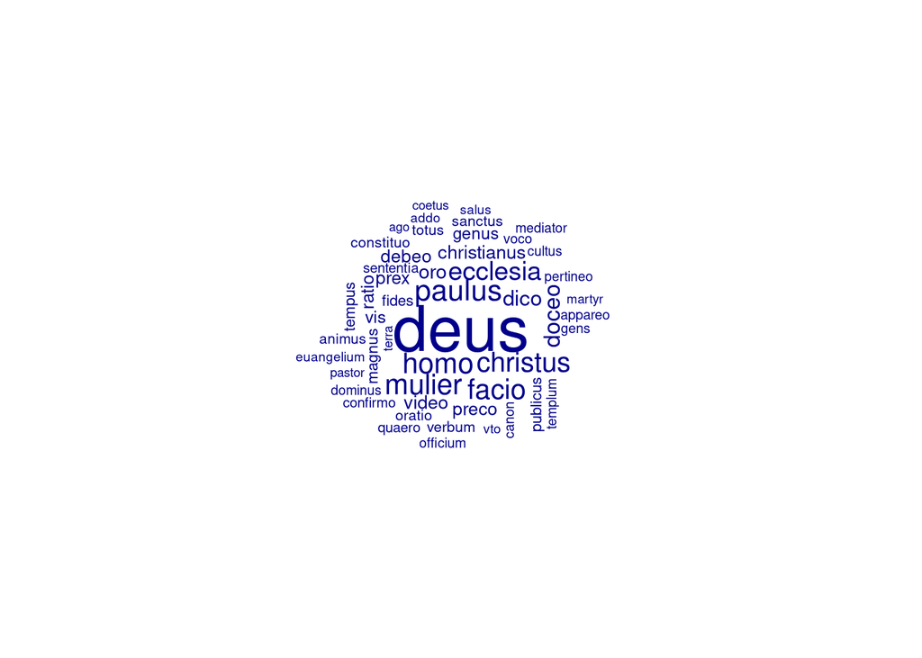

```r
library(quanteda.textplots)
textplot_wordcloud(text_dfm, max_words = 50)
```

## 14.1 Ameliorer la visualisation

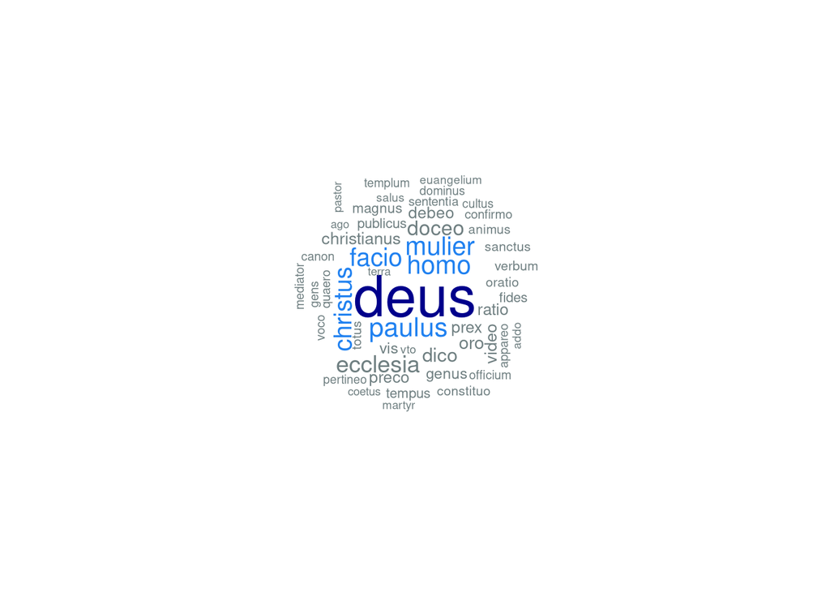

```r
textplot_wordcloud(
  text_dfm,
  max_words = 50,
  color = c("#6f7f81", "#2081f0", "darkblue"),  # Custom color gradient
  random_order = FALSE,                     # Disable random placement
  rotation = 0.25,                         # 25% of words rotated (for aesthetics)
  font = "sans"                           # Change font (try "sans", "serif", "mono")
)
```

## 14.2 Choosing a word

1. on choisit un mot pour analyser ses co-occurrence

```r
coocTerm <- "mulier"
```

2. on compte les termes co-occurrent :

```r
coocCounts <- t(text_dfm) %*% text_dfm
dim(coocCounts) # to check the matrix dimension
```

```
## [1] 264 264
```

```r
as.matrix(coocCounts[15:17, 15:17])
```

```
##             features
## features     argumentum pastor ecclesia
##   argumentum          7      1        3
##   pastor              1     16        8
##   ecclesia            3      8       63
```

```r
text_dfm_trimmed <- dfm_trim(text_dfm, min_termfreq = 5)  # Example: keep terms appearing ≥5 times
coocCounts <- t(text_dfm_trimmed) %*% text_dfm_trimmed
```

```r
coocCounts <- fcm(text_dfm, context = "document", count = "frequency")
```

```r
# Convert to a full matrix (if it's sparse)
cooc_matrix <- as.matrix(coocCounts)

# Find top co-occurring pairs (excluding diagonal)
diag(cooc_matrix) <- 0  # Ignore self-co-occurrences
top_cooc <- sort(cooc_matrix, decreasing = TRUE)[1:10]  # Top 10
print(top_cooc)
```

```
##  [1] 46 40 31 29 28 24 21 20 20 18
```

```r
# Get all co-occurrences for "mulier"
#mulier_cooc <- sort(coocCounts["mulier", ], decreasing = TRUE)
#head(mulier_cooc, 10)  # Top 10 co-occurring words
```

# 15 Network visualisation

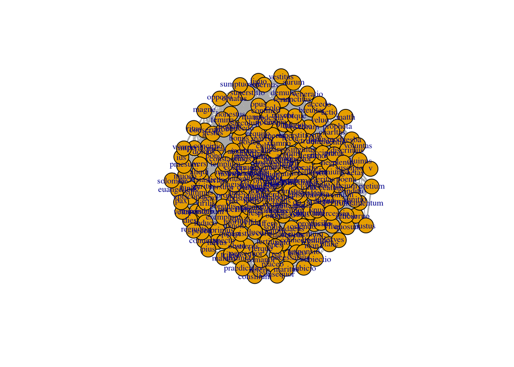

```r
library(igraph)
# Convert to a graph (ignoring low-frequency edges)
graph <- graph_from_adjacency_matrix(coocCounts, weighted = TRUE, mode = "undirected")
# Simplify (remove loops and multiple edges)
graph <- simplify(graph)
# Plot the graph
plot(graph, edge.width = E(graph)$weight, vertex.label.cex = 0.7)
```

```r
# Keep only edges with weight >= threshold (e.g., 5)
graph <- graph_from_adjacency_matrix(
  coocCounts,
  weighted = TRUE,
  mode = "undirected"
)
graph <- delete_edges(graph, E(graph)[E(graph)$weight < 5])  # Adjust threshold
graph <- simplify(graph)  # Remove loops
```

```r
graph <- delete_vertices(graph, V(graph)[degree(graph) == 0])
```

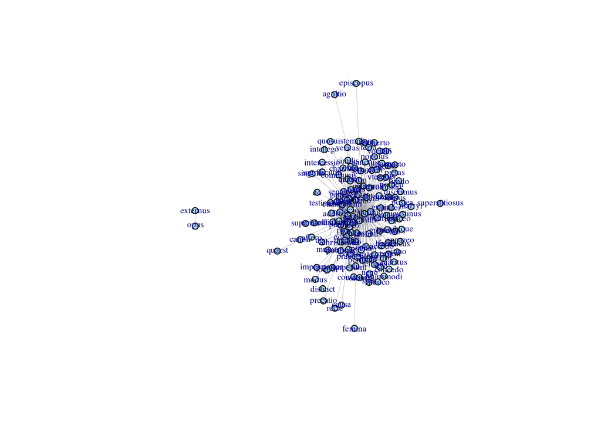

```r
plot(graph,
     edge.width = E(graph)$weight / max(E(graph)$weight) * 3,  # Scale edge width
     vertex.size = 5,                                         # Smaller nodes
     vertex.label.cex = 0.6,                                  # Smaller labels
     vertex.color = "lightblue",                              # Node color
     layout = layout_with_fr(graph))                          # Force-directed layout
```

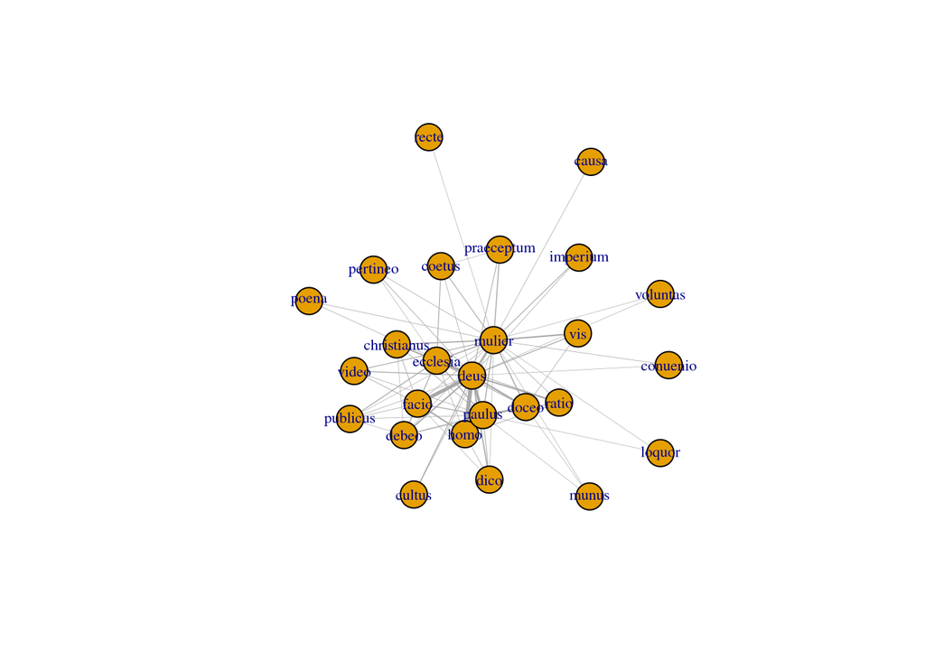

```r
subgraph <- make_ego_graph(graph, order = 1, nodes = "mulier")[[1]]
plot(subgraph,
     edge.width = E(subgraph)$weight / max(E(subgraph)$weight) * 3,
     vertex.label.cex = 0.7)
```

# 16 interactive visualisation

for an interactive visualisation use visNetwork : more information https://datastorm-open.github.io/visNetwork/

```r
library(visNetwork)
nodes <- data.frame(id = V(graph)$name, label = V(graph)$name)
edges <- data.frame(from = ends(graph, E(graph))[,1],
                    to = ends(graph, E(graph))[,2],
                    width = E(graph)$weight)
visNetwork(nodes, edges) %>%
  visOptions(highlightNearest = TRUE, nodesIdSelection = TRUE)
```

[interactive chart not shown]

# 17 cibler sur mulier

```r
library(visNetwork)

# 1. Convert the subgraph to visNetwork format
nodes <- data.frame(
  id = V(subgraph)$name,
  label = V(subgraph)$name,
  title = V(subgraph)$name,  # Tooltip on hover
  value = degree(subgraph),  # Node size by degree
  color = "#b3ade6"        # Customize color
)

edges <- data.frame(
  from = ends(subgraph, E(subgraph))[, 1],
  to = ends(subgraph, E(subgraph))[, 2],
  width = E(subgraph)$weight / max(E(subgraph)$weight) * 10,  # Scale edge width
  smooth = TRUE  # Curved edges
)

# 2. Create interactive plot
visNetwork(nodes, edges) %>%
  visNodes(font = list(size = 20)) %>%
  visEdges(selectionWidth = 2) %>%
  visOptions(
    highlightNearest = list(enabled = TRUE, degree = 1, hover = TRUE),
    nodesIdSelection = TRUE  # Dropdown menu to select nodes
  ) %>%
  visLayout(randomSeed = 42)  # For consistent layout
```

[interactive chart not shown]